# Data: Google Trends and the Build

Monday · Session 5

Diego A. Guerrero

GDP Growth Nowcasting Workshop | Trinidad and Tobago

## Learning objectives

- Download and clean **Google Trends** search data
- Turn every source into **one quarterly panel**: frequencies, seasonality, growth rates
- Run a first regression, and check whether it survives without 2020

# Google Trends

Part 1

What people search for, every month, with no lag

## Search intensity as an indicator

Google Trends reports how popular a search term is, **0–100**, relative to its own peak in the period and place you ask for.

- **Consumption**: `amazon`, `shein`, `temu`, `pricesmart`, `kfc`
- **Labour market**: `caribbean jobs`, `linkedin`
- **Tourism and travel**: `tobago ferry`, `tobago hotel`, `flights miami`
- **Finance**: `rbc`, `first citizens bank`, `island finance`

Monthly, free, and available **days** after the month ends.

## Trinidad and Tobago: monthly search interest

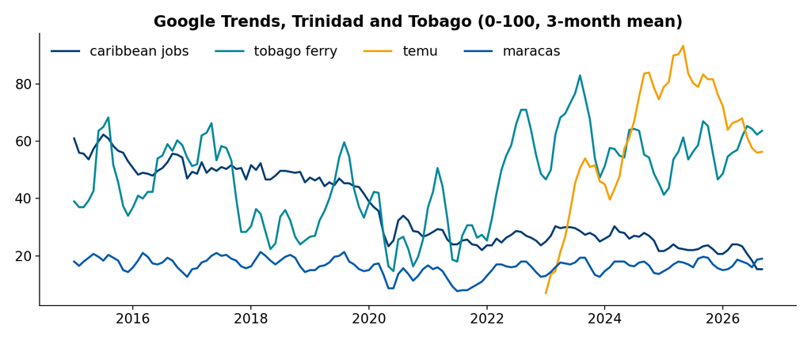

Temu only exists from 2023; `caribbean jobs` halves with COVID and never recovers. Each term tells its own story.

## Lesson 1. One term per query

Google rescales **within a query**: a batch of five terms is scaled to its largest member, and the small ones are crushed to 0–2.

```python
from trendspy import Trends
tr = Trends(request_delay=2.0)
df = tr.interest_over_time("tobago ferry", geo="TT", timeframe="all")
```

Each keyword is its own predictor, so cross-term comparability buys nothing.

## Lesson 2. The library

### ✗ `pytrends`

Archived in April 2025. Fails with `429` on the **first** call. Do not try to fix it.

### ✓ `trendspy`

Maintained, no API key. In our tests: dozens of terms per run, 2004 to today.

## Lesson 3. Google has limits

- Around 30–40 consecutive queries before a `429 Too Many Requests`
- After that, a cooldown of several minutes
- **Twenty people on one office IP will hit it fast**: in class, each of you queries **three or four terms**, and we use the shipped `data/gtrends.csv` for the rest
- Fallback: download by hand from trends.google.com (Explore → one term → *Trinidad and Tobago* → *2004–present* → ⬇ CSV)

# Data cleaning

Part 2

## The build

From one CSV per source to one monthly panel:

1. Read every `raw/*.csv`, rename columns to **tickers** (`RGDP0000` GDP, `RCPI0000` CPI, `UGTR…` Google Trends, `UNTL…` lights, `RENE…` energy)
2. Daily → monthly; quarterly series sit on the quarter’s last month
3. **Deflate** nominal series by the CPI
4. **Seasonally adjust** each series at its own frequency (12 for monthly, 4 for quarterly)
5. **Growth rates** (quarter on quarter) for the models